# Problem Statement

The sinking of the Titanic is one of the most infamous shipwrecks in history. On April 15, 1912, during her maiden voyage, the widely considered “unsinkable” RMS Titanic sank after colliding with an iceberg. Unfortunately, there weren’t enough lifeboats for everyone onboard, resulting in the death of 1502 out of 2224 passengers and crew.

While there was some element of luck involved in surviving, it seems some groups of people were more likely to survive than others. Some of the predictor variables include the age, sex, fare, cabin of the passengers.

The outcome of this predictive modelling is to predict a passenger's likelihood of survival in the titanic shipwreck

### Import Relevant Package

```python
import pandas as pd
import numpy as np
import seaborn as sns
import matplotlib.pyplot as plt
from sklearn.metrics import f1_score, roc_auc_score, accuracy_score
from sklearn.model_selection import StratifiedKFold, RandomizedSearchCV
```

```python
data = pd.read_csv('data/data.csv')
```

```python
data.head()
```

|  | PassengerId | Survived | Pclass | Name | Sex | Age | SibSp | Parch | Ticket | Fare | Cabin | Embarked |
| --- | --- | --- | --- | --- | --- | --- | --- | --- | --- | --- | --- | --- |
| 0 | 1 | 0 | 3 | Braund, Mr. Owen Harris | male | 22.0 | 1 | 0 | A/5 21171 | 7.2500 | NaN | S |
| 1 | 2 | 1 | 1 | Cumings, Mrs. John Bradley (Florence Briggs Th... | female | 38.0 | 1 | 0 | PC 17599 | 71.2833 | C85 | C |
| 2 | 3 | 1 | 3 | Heikkinen, Miss. Laina | female | 26.0 | 0 | 0 | STON/O2. 3101282 | 7.9250 | NaN | S |
| 3 | 4 | 1 | 1 | Futrelle, Mrs. Jacques Heath (Lily May Peel) | female | 35.0 | 1 | 0 | 113803 | 53.1000 | C123 | S |
| 4 | 5 | 0 | 3 | Allen, Mr. William Henry | male | 35.0 | 0 | 0 | 373450 | 8.0500 | NaN | S |

### Data Exploration

Survived

From the chart below, the target variable 'Survived' is imbalanced and has more passengers that did not survive.

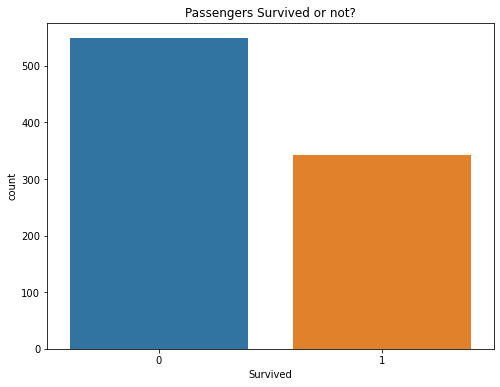

```python
fig, ax = plt.subplots(figsize=(8,6))
sns.countplot(data['Survived'], ax=ax)
ax.set_title('Passengers Survived or not?')
plt.show()
```

```python
data.Survived.value_counts(normalize=True)
```

```
0    0.616162
1    0.383838
Name: Survived, dtype: float64
```

Age

From the chart below, we notice that the ages of the passgengers is a little skewed to the right and has a mean of about 30

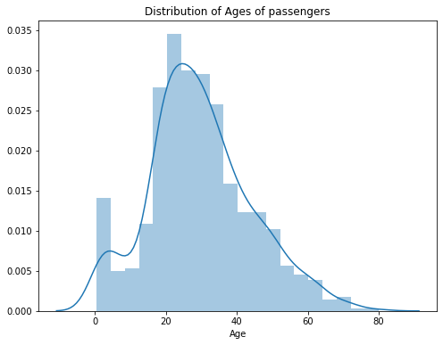

```python
fig, ax = plt.subplots(figsize=(8,6))
sns.distplot(data['Age'])
ax.set_title('Distribution of Ages of passengers')
plt.show()
```

Pclass

The ticket class of passengers

Ticket class: 1 = 1st, 2 = 2nd, 3 = 3rd

```python
survived = data[data['Survived']==1]['Pclass'].value_counts()
dead = data[data['Survived']==0]['Pclass'].value_counts()
comb_df = pd.DataFrame([survived,dead])
comb_df.index = ['Survived','Dead']
```

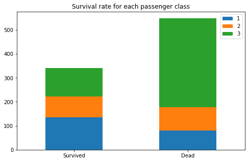

```python
g = comb_df.plot(kind='bar',stacked=True, figsize=(8,5))
g.set_xticklabels(g.get_xticklabels(), rotation=0)
g.set_title('Survival rate for each passenger class')
plt.show()
```

From the plot above we see that passengers of the third class did not have a high survival rate

### Data Processing

```python
data.shape
```

```
(891, 12)
```

Check for missing values

```python
data.isna().sum()
```

```
PassengerId      0
Survived         0
Pclass           0
Name             0
Sex              0
Age            177
SibSp            0
Parch            0
Ticket           0
Fare             0
Cabin          687
Embarked         2
dtype: int64
```

```python
data['Age'].fillna(data.Age.mean(), inplace=True)
data['Cabin'].fillna(data.Cabin.mode()[0], inplace=True)
data['Embarked'].fillna(data.Embarked.mode()[0], inplace=True)
```

```python
sum(data.isna().sum())
```

```
0
```

Feature Engineering

SibSp feature describes the number of siblings / spouses aboard the Titanic  
Parch feature is the number of parents / children aboard the Titanic

```python
data['Family_size'] = data ['SibSp'] + data['Parch'] + 1     # +1 represents the indiviual themselves
```

```python
data['Has_Family'] = data['Family_size'].apply(lambda x: 1 if x > 1 else 0)
```

Cabin is the Cabin number of passengers

```python
data['Cabin'].fillna('Unknown', inplace=True)
```

```python
data['Cabin'] = data['Cabin'].str[0]
```

Extract relevant keywords from Name of passengers

```python
data['Title'] = data['Name'].str.extract(' ([A-Za-z]+)\.', expand=False)
```

```python
TARGET_COL = 'Survived'
cols_to_drop = ['Survived', 'PassengerId', 'Ticket', 'Name']
```

```python
target = data[TARGET_COL]
```

```python
data.drop(columns=cols_to_drop, inplace=True)
```

Encode Categorical and Text Columns

```python
object_cols = [col for col in data.columns if data[col].dtype==object]
```

```python
object_cols
```

```
['Sex', 'Cabin', 'Embarked', 'Title']
```

Label Encode object columns

```python
for col in object_cols:
    data[col] = pd.factorize(data[col])[0]
```

```python
data.head()
```

|  | Pclass | Sex | Age | SibSp | Parch | Fare | Cabin | Embarked | Family_size | Has_Family | Title |
| --- | --- | --- | --- | --- | --- | --- | --- | --- | --- | --- | --- |
| 0 | 3 | 0 | 22.0 | 1 | 0 | 7.2500 | 0 | 0 | 2 | 1 | 0 |
| 1 | 1 | 1 | 38.0 | 1 | 0 | 71.2833 | 1 | 1 | 2 | 1 | 1 |
| 2 | 3 | 1 | 26.0 | 0 | 0 | 7.9250 | 0 | 0 | 1 | 0 | 2 |
| 3 | 1 | 1 | 35.0 | 1 | 0 | 53.1000 | 1 | 0 | 2 | 1 | 1 |
| 4 | 3 | 0 | 35.0 | 0 | 0 | 8.0500 | 0 | 0 | 1 | 0 | 0 |

The 2 algorithms that I've selected for this predictive task is Random Forest and K-Nearest Neighbors classifiers

```python
from sklearn.ensemble import RandomForestClassifier
from sklearn.neighbors import KNeighborsClassifier
```

```python
n_folds = 10
random_state = 2021
```

```python
def ApplyStratifiedKFold(train_features, train_targets, model):
    '''
    function to apply Statified KFold cross validation

    args:
        train_features: independent feature data to split into n_folds.

        train_targets: dependent target data to split into n_folds.

        model: Machine learning model to fit data on.

    return:
        eval_dfs: a list of pandas datafames that contains metric results for each n_fold.

    '''
    kfold=StratifiedKFold(n_splits=n_folds)
    index=1
    eval_dfs = []
    for train_index, test_index in kfold.split(train_features, train_targets):
        print('Number {}, Fold'.format(index))
        X_train, X_val = train_features.iloc[train_index], train_features.iloc[test_index]
        y_train, y_val = train_targets.iloc[train_index], train_targets.iloc[test_index]

        curr_model = FitModel(model, X_train, y_train)
        eval_df = EvaluateModel(curr_model, X_val, y_val)

        eval_dfs.append(eval_df)
        index+=1

    return eval_dfs
```

```python
def FitModel(model, X, y):
    '''
    function to fit our machine learning model

    args:
        model: Machine Learning model (sklearn)

        X: Training set feature data (independent features)

        y: Training set target data (dependent feature)
    returns:
        model: A fitted model on the dataset
    '''
    model.fit(X,y)
    return model
```

```python
def EvaluateModel(model, test_features, test_targets, threshold=0.5):
    '''
    function to evaluate the performance of a model on the test data

    args:
        model: The model to evaluate

        test_features: the independent feature values of the test data to be evaluated

        test_targets: the dependent target values of the test data to be evaluated

        threshold: threshold to apply on predictions in creating categorical values.

    returns:
        eval_df: A pandas datafame that contains metric results
    '''

    eval_df = pd.DataFrame()
    cont_preds = model.predict_proba(test_features)[:,1]
    cat_preds = pd.Series(cont_preds).apply(lambda x: 0 if x <= threshold else 1)

    eval_df['Accuracy_score'] = pd.Series(accuracy_score(test_targets, cat_preds), name='Accuracy')
    eval_df['F-Measure_score'] = pd.Series(f1_score(test_targets, cat_preds), name='f1_score')
    eval_df['AUC_score'] = pd.Series(roc_auc_score(test_targets, cont_preds), name = 'AUC')


    return eval_df
```

### K-Nearest Neighbors classifier

HyperParameter Search for model

```python
knn_param_grid = {
    'n_neighbors': [3, 5, 8, 12, 15, 20, 30, 50],
    'weights' : ['uniform', 'distance'],
    'algorithm' : ['ball_tree', 'kd_tree', 'brute'],
    'p': [1,2]
}
```

```python
knn_rand_search = RandomizedSearchCV(n_iter=30, estimator=KNeighborsClassifier(), random_state=random_state,
                                     param_distributions=knn_param_grid, scoring='roc_auc', n_jobs=4, cv=10)
```

```python
knn_rand_search.fit(data, target)
```

```
RandomizedSearchCV(cv=10, estimator=KNeighborsClassifier(), n_iter=30, n_jobs=4,
                   param_distributions={'algorithm': ['ball_tree', 'kd_tree',
                                                      'brute'],
                                        'n_neighbors': [3, 5, 8, 12, 15, 20, 30,
                                                        50],
                                        'p': [1, 2],
                                        'weights': ['uniform', 'distance']},
                   random_state=2021, scoring='roc_auc')
```

```python
knn_eval_df = ApplyStratifiedKFold(data, target, knn_rand_search.best_estimator_)
```

```
Number 1, Fold
Number 2, Fold
Number 3, Fold
Number 4, Fold
Number 5, Fold
Number 6, Fold
Number 7, Fold
Number 8, Fold
Number 9, Fold
Number 10, Fold
```

```python
knn_eval_df = pd.concat(knn_eval_df)
knn_eval_df.reset_index(drop=True, inplace=True)
new_index_name = ['KFold'+str(i+1) for i in range(n_folds)]
```

```python
rename_dict = {range(n_folds)[i]: new_index_name[i] for i in range(n_folds)}
knn_eval_df.rename(rename_dict, inplace=True)
```

```python
knn_eval_df
```

|  | Accuracy_score | F-Measure_score | AUC_score |
| --- | --- | --- | --- |
| KFold1 | 0.711111 | 0.638889 | 0.781039 |
| KFold2 | 0.741573 | 0.666667 | 0.824599 |
| KFold3 | 0.752809 | 0.620690 | 0.712567 |
| KFold4 | 0.786517 | 0.753247 | 0.873262 |
| KFold5 | 0.775281 | 0.696970 | 0.823529 |
| KFold6 | 0.741573 | 0.596491 | 0.794385 |
| KFold7 | 0.853933 | 0.793651 | 0.852139 |
| KFold8 | 0.730337 | 0.636364 | 0.765775 |
| KFold9 | 0.797753 | 0.735294 | 0.868984 |
| KFold10 | 0.775281 | 0.677419 | 0.849471 |

### Random Forest Classifier

HyperParameter Search for model

```python
rfc_param_grid = {}
rfc_param_grid['criterion'] = ['gini', 'entropy']
rfc_param_grid['max_depth'] = [5, 8, 12, 15, 20, None]
rfc_param_grid['min_samples_leaf'] = [0.005, 0.01, 0.05, 0.1, 0.15, 0.2]
rfc_param_grid['min_impurity_decrease'] = [0.001, 0.006, 0.03, 0.00001, 5e-06, 5e-07]
```

```python
rfc_rand_search = RandomizedSearchCV(n_iter=30, estimator=RandomForestClassifier(random_state=random_state), random_state=random_state,
                                     param_distributions=rfc_param_grid, scoring='f1', n_jobs=4, cv=10)
```

```python
rfc_rand_search.fit(data, target)
```

```
RandomizedSearchCV(cv=10, estimator=RandomForestClassifier(random_state=2021),
                   n_iter=30, n_jobs=4,
                   param_distributions={'criterion': ['gini', 'entropy'],
                                        'max_depth': [5, 8, 12, 15, 20, None],
                                        'min_impurity_decrease': [0.001, 0.006,
                                                                  0.03, 1e-05,
                                                                  5e-06,
                                                                  5e-07],
                                        'min_samples_leaf': [0.005, 0.01, 0.05,
                                                             0.1, 0.15, 0.2]},
                   random_state=2021, scoring='f1')
```

```python
rfc_eval_df = ApplyStratifiedKFold(data, target, rfc_rand_search.best_estimator_)
```

```
Number 1, Fold
Number 2, Fold
Number 3, Fold
Number 4, Fold
Number 5, Fold
Number 6, Fold
Number 7, Fold
Number 8, Fold
Number 9, Fold
Number 10, Fold
```

```python
rfc_eval_df = pd.concat(rfc_eval_df)
rfc_eval_df.reset_index(drop=True, inplace=True)
```

```python
rename_dict = {range(n_folds)[i]: new_index_name[i] for i in range(n_folds)}
rfc_eval_df.rename(rename_dict, inplace=True)
```

```python
rfc_eval_df
```

|  | Accuracy_score | F-Measure_score | AUC_score |
| --- | --- | --- | --- |
| KFold1 | 0.777778 | 0.696970 | 0.832727 |
| KFold2 | 0.865169 | 0.812500 | 0.900535 |
| KFold3 | 0.741573 | 0.610169 | 0.716845 |
| KFold4 | 0.898876 | 0.876712 | 0.906952 |
| KFold5 | 0.876404 | 0.840580 | 0.904011 |
| KFold6 | 0.831461 | 0.761905 | 0.873797 |
| KFold7 | 0.853933 | 0.786885 | 0.865241 |
| KFold8 | 0.775281 | 0.655172 | 0.886631 |
| KFold9 | 0.887640 | 0.848485 | 0.946257 |
| KFold10 | 0.820225 | 0.757576 | 0.898942 |

```python
from scipy.stats import sem
```

```python
def find_sem(metric, model, return_err=False):
    '''
    args:
        metric: metric data to find standard error of the mean (Accuracy, F-Measure, AUC)

        model: KNN or RFC

        return_err: whether to return standard error value or not (True, False)
    '''

    if model.lower() == 'knn':
        err = sem(knn_eval_df['{}_score'.format(metric)])
        print('The standard error of mean of {} score for the {}-classifier = {}'.format(metric, model.upper(), err))

    elif model.lower() == 'rfc':
        err = sem(rfc_eval_df['{}_score'.format(metric)])
        print('The standard error of mean of {} score for the {}-classifier = {}'.format(metric, model.upper(), err))

    if return_err:
        return err
```

### Paired t-test

```python
def metric_df(metric):
    '''
    function to make pandas dataframe of metric result of the 2 models

    args:
        metric: metric to perform test e.g (Accuracy, AUC, F-Measure)

    returns:
        df: pandas dataframe of metric result of the 2 models
    '''

    df = pd.DataFrame()
    df['KNN_{}'.format(metric)] = knn_eval_df['{}_score'.format(metric)]
    df['RFC_{}'.format(metric)] = rfc_eval_df['{}_score'.format(metric)]
    df.index = new_index_name

    return df
```

### Null hypothesis (H <sub>0</sub> ) : u<sub>d</sub> = 0, which translates to the mean difference between K-Neighbors and Random Forest metric results is equal to 0.

### Alternative hypothesis (H<sub>1</sub>) : u<sub>d</sub> ≠ 0, which translates to the mean difference between K-Neighbors and Random Forest metric results is not equal to 0

### level of significance = 0.05 : p = 5%

The metric I would be using for the t-test is Accuracy.

Accuracy is the degree to which the information correctly describes the phenomena it was designed to measure.

Accuracy is the fraction of predictions our model got right : Accuracy = Number of correct predictions / Total number of predictions.

For this use-case, Accuracy is the fraction of passengers, our model was able to predict survuved the titanic shipwreck.

#### Accuracy

```python
df = metric_df('Accuracy')
```

```python
df.describe()
```

|  | KNN_Accuracy | RFC_Accuracy |
| --- | --- | --- |
| count | 10.000000 | 10.000000 |
| mean | 0.766617 | 0.832834 |
| std | 0.040800 | 0.053320 |
| min | 0.711111 | 0.741573 |
| 25% | 0.741573 | 0.788390 |
| 50% | 0.764045 | 0.842697 |
| 75% | 0.783708 | 0.873596 |
| max | 0.853933 | 0.898876 |

### PAIRED SAMPLE T-TEST ASSUMPTIONS

In order for the paired sample t-test results to be trusted, the following assumptions need to be met:

The observations are independent.

The Dependent Variable should be approximately normally distributed. The paired sample t-test is very sensitive to this violation. when there is a violation of normality, if it’s not a major violation then the test results can be considered valid.

The Dependent Variable should not contain any significant outliers.

#### Standard Error

```python
find_sem('Accuracy', 'knn')
```

```
The standard error of mean of Accuracy score for the KNN-classifier = 0.012902100774242491
```

```python
find_sem('Accuracy', 'rfc')
```

```
The standard error of mean of Accuracy score for the RFC-classifier = 0.016861329120951035
```

The standard error for the K-Neighbors classifier is smaller than the standard error of the Random forest classifier.

However the standart error for both variables is relatively small, meaning that the values are not very spread out from the mean of the data.

```python
from scipy import stats
```

First let’s check for any significant outliers in each of the variables.

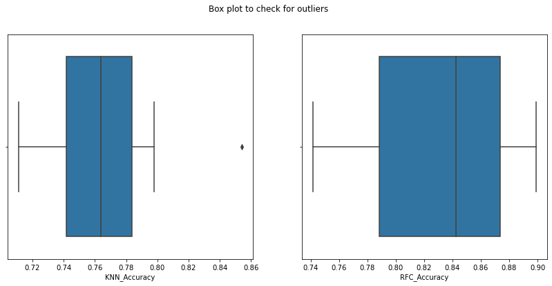

```python
fig, ax = plt.subplots(1,2, figsize=(14,6))
sns.boxplot(df.KNN_Accuracy, ax=ax[0])
sns.boxplot(df.RFC_Accuracy, ax=ax[1])
fig.suptitle('Box plot to check for outliers')
plt.show()
```

There appears to be a significant outlier for the K-Neighbors and no outlier for the Random Forest classifier, however we would continue with the test regardless.

Now to test that the data came from a normal distribution.

There are two ways one can test for normal distribution – make a histogram, and/or use a statistical test.

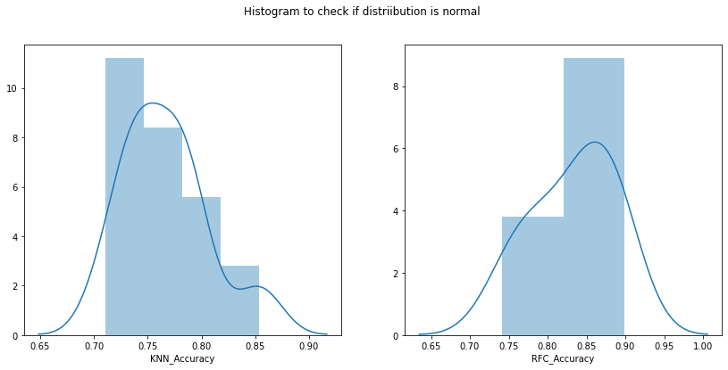

```python
fig, ax = plt.subplots(1,2, figsize=(14,6))
sns.distplot(df.KNN_Accuracy, ax=ax[0])
sns.distplot(df.RFC_Accuracy, ax=ax[1])
fig.suptitle('Histogram to check if distriibution is normal')
plt.show()
```

The histograms of our data does not seem to be completely normally distributed.

The distribution for the K-Neighbors classifier seems a little skewed to the right, while the distribution of the Random forest classifier seems to be normally distributed but with a tiny skew to the left.

Let’s test this statistically to see if the data is normally distributed.

To test this, I use the Shapiro-Wilk test for normality, The output is not labeled, however the first value is the W test value, and the second value is the p-value.

```python
stats.shapiro(df['KNN_Accuracy'])
```

```
(0.9418829679489136, 0.5741506814956665)
```

```python
stats.shapiro(df['RFC_Accuracy'])
```

```
(0.9361581206321716, 0.5111076831817627)
```

Both variables fufill the assumption of normality

To conduct the paired sample t-test, I'll use the stats.ttest_rel() method.

```python
stats.ttest_rel(df['KNN_Accuracy'], df['RFC_Accuracy'])
```

```
Ttest_relResult(statistic=-4.551463580729523, pvalue=0.0013830412098977942)
```

The results are statistically significant!

Therefore I reject the null hypothesis in support of the alternative.

Alternative hypothesis (H<sub>1</sub>) : u<sub>d</sub> ≠ 0, which translates to the mean difference between K-Neighbors and Random Forest Accuracies is not equal to 0